# 第十周作业参考答案

新旧教材的题目说明：

旧教材4.1与新教材4.1相同；

旧教材4.3包含在新教材4.6中；

旧教材4.6包含在新教材4.8中；

旧教材4.7与新教材4.9相同。

所以以下按新教材的题目顺序。

#新4.2

首先读入数据，然后分别采用自己编写的函数数和dunn.test包中的dunn.test()函数进行Dunn检验，得到的结果一致。

```r
#读入数据
A <- c(80, 203, 236, 252, 284, 368, 457, 393)
B <- c(133, 180, 100, 160)
C <- c(156, 295, 320, 448, 465, 481, 279)
D <- c(194, 214, 272, 330, 386, 475)
ABCD <- c(A,B,C,D)
```

数据中没有结。

##方法一：编写函数

```r
#每组样本的样本量
leng <- sapply(list(A, B, C, D), length)
n <- sum(leng)

#计算混合秩
Rank <- rank(ABCD, ties.method = "average")

#将混合秩根据每组样本的长度拆分，得到每组样本的秩
#结果为列表类型
R_cond <- split(Rank, rep(1:4, leng))

#求出四组药物的样本的秩平均
R_cond_avg <- sapply(R_cond, mean)

#共有4组样本
k <- 4
alpha_star <- 0.05/(k*(k-1))

#进行两两之间的Dunn检验，返回p值
dunn_pair_func <- function(Ri_mean, Rj_mean, ni, nj, namei, namej){
  R_mean_diff <- abs(Ri_mean - Rj_mean)
#计算两平均秩差的标准误差
  SE <- sqrt((n*(n+1))*(1/ni+1/nj)/12)
  d_ij <- R_mean_diff/SE
  p <- 1 - pnorm(d_ij)
#输出p值
  print(paste("第", namei, "组和第", namej, "组进行Dunn检验，得到p=", round(p,5), sep = ""))
#sig表示是否显著，显著则为1
  sig <- 0
  if(p < alpha_star){
    sig <- 1
#第i与第j处理之间有显著差异
    print(paste("第", namei, "组和第", namej, "组之间有显著差异", sep = ""))
  }else{
    sig <- 0
#第i与第j处理之间没有显著差异
    print(paste("第", namei, "组和第", namej, "组之间没有显著差异", sep = ""))
  }
#返回p值和是否显著
  return(list(p = p, sig = sig))
}

#依次进行A、B、C、D四组中，两两之间的Dunn检验
k <- 4
#共有(4*3)/2=6组
p_dunn_pair <- rep(0, 6)
sig_dunn_pair <- rep(0, 6)
name_drug <- c("A", "B", "C", "D")

group_order <- 0

#依次进行两两之间的Dunn检验
for(i in 1:3){
  for(j in (i+1):4){
    group_order <- group_order+1
    dunn_pair_res <-
      dunn_pair_func(R_cond_avg[i], R_cond_avg[j],
                     leng[i], leng[j],
                     name_drug[i], name_drug[j])
#保存Dunn检验的p值
    p_dunn_pair[group_order] <- dunn_pair_res[[1]]
#保存检验结果是否显著，显著则为1
    sig_dunn_pair[group_order] <- dunn_pair_res[[2]]

  }
}
```

```
## [1] "第A组和第B组进行Dunn检验，得到p=0.02292"
## [1] "第A组和第B组之间没有显著差异"
## [1] "第A组和第C组进行Dunn检验，得到p=0.16475"
## [1] "第A组和第C组之间没有显著差异"
## [1] "第A组和第D组进行Dunn检验，得到p=0.33749"
## [1] "第A组和第D组之间没有显著差异"
## [1] "第B组和第C组进行Dunn检验，得到p=0.00292"
## [1] "第B组和第C组之间有显著差异"
## [1] "第B组和第D组进行Dunn检验，得到p=0.01238"
## [1] "第B组和第D组之间没有显著差异"
## [1] "第C组和第D组进行Dunn检验，得到p=0.30851"
## [1] "第C组和第D组之间没有显著差异"
```

```r
sig_dunn_pair <- ifelse(sig_dunn_pair == 1, "显著", "不显著")

#以表格形式输出Dunn检验的结果
df_dunn_res <- data.frame(p_dunn_pair, sig_dunn_pair)
rownames(df_dunn_res) <- paste(c("A", "A", "A", "B", "B", "C"), "VS", c("B", "C", "D", "C", "D", "D"))
colnames(df_dunn_res) <- c("p值", "是否有显著差异")
knitr::kable(df_dunn_res, format = "html")
```

|  | p值 | 是否有显著差异 |
| --- | --- | --- |
| A VS B | 0.0229169 | 不显著 |
| A VS C | 0.1647506 | 不显著 |
| A VS D | 0.3374934 | 不显著 |
| B VS C | 0.0029240 | 显著 |
| B VS D | 0.0123754 | 不显著 |
| C VS D | 0.3085108 | 不显著 |

##方法二：使用dunn.test包中的dunn.test()函数

```r
library(dunn.test)
#共有4种处理
k <- 4
alpha_star <- 0.05/(k*(k-1))
#将函数中的alpha参数调整为2*alpha_star
dunn.test(x = list(A, B, C, D), alpha = 2*alpha_star)
```

```
##   Kruskal-Wallis rank sum test
##
## data: x and group
## Kruskal-Wallis chi-squared = 8.0721, df = 3, p-value = 0.04
##
##
##                            Comparison of x by group
##                                 (No adjustment)
## Col Mean-|
## Row Mean |          1          2          3
## ---------+---------------------------------
##        2 |   1.996920
##          |     0.0229
##        3 |  -0.975119  -2.756186
##          |     0.1648    0.0029*
##        4 |  -0.419313  -2.245268   0.500076
##          |     0.3375     0.0124     0.3085
##
## alpha = 0.008333333
## Reject Ho if p <= alpha/2
```

只有B与C有显著性差别。

#新4.3

##Bonferroni检验

###方法一：根据定义计算

有10个假设检验

$$H_{0j}:\mu_{j}=0 \ vs\ H_{1j}:\mu_{j}≠0,\ j = 1,2,...,m$$

令$p_1,p_2,...,p_m$是这$m$个检验的$p$值。

如果$p_j<\alpha/{m}$，则拒绝原假设。

```r
p <- c(0.00017, 0.00448, 0.00671, 0.00907, 0.01220, 0.33626, 0.39341, 0.53882, 0.58125, 0.98617)
#一共有m个检验
m <- length(p)
#Bonferroni检验，当pj<alpha/m时拒绝原假设
alpha <- 0.05
alpha_Bon <- 0.05/m
#当pj<alpha/m时拒绝原假设，得到Bonferroni检验拒绝的原假设的个数
sig_Bon <- sum(p < alpha_Bon)
sig_Bon
```

```
## [1] 2
```

###方法二：使用p.adjust()函数

使用`p.adjust()`函数，设置参数`method="bonferroni"`，计算Bonferroni检验的调整后的p值。

调整后的p值小于0.05时拒绝原假设。

```r
p_Bon <- p.adjust(p, method="bonferroni")
sum(p_Bon<0.05)
```

```
## [1] 2
```

###方法三：使用gMAP包中的bonferroni.test()函数。

`bonferroni.test()`函数设置参数`adjPValues = FALSE`，函数输出每一个p值是否被拒绝，拒绝则输出`TRUE`。

```r
library(gMCP)
sig_Bon <- 0
for(i in 1:m){
  sig_Bon <- sig_Bon +
    bonferroni.test(p[i], weight = rep(0.1, m), adjPValues = FALSE)
  }
sig_Bon
```

```
## [1] 2
```

Bonferroni检验拒绝的原假设的个数是2个。

##BH检验

###方法一：根据定义计算

(1)$p_{(1)} \leqslant p_{(2)} \leqslant \cdots \leqslant p_{(m)}$ 表示排序后的 $p$值;

(2)$H_{(i)}$ 是对应于 $p_{(i)}$ 的原假设，定义Bonferroni-型多重检验过程:

3. 令 $k=\max \left\{i: p_{(i)} \leqslant \frac{i}{m} \alpha\right\}$.
4. 拒绝所有的 $H_{(i)}, i=1,2, \cdots, k$.

```r
#从小到大排序
p_sort <- sort(p)
k <- NULL
alpha <- 0.05
for(i in 1:m){
  if(p_sort[i] <= i*alpha/m){
    k <- c(k, i)
  }
}
k <- max(k)
#拒绝第一个至第k个假设检验的原假设
sig_BH <- k
sig_BH
```

```
## [1] 5
```

###方法二：使用p.adjust()函数

使用`p.adjust()`函数，设置参数`method="BH"`，计算BH检验的调整后的p值。

调整后的p值小于0.05时拒绝原假设。

```r
p_BH <- p.adjust(p,method="BH")
sum(p_BH<0.05)
```

```
## [1] 5
```

###方法三：使用sgof包中的BH()函数

函数返回值中的Rejections是拒绝的个数。

```r
library(sgof)
BH(p, alpha = 0.05)$Rejections
```

```
## [1] 5
```

BH检验拒绝的原假设的个数是5个。

#新4.6(旧4.3)

本题是完全随机区组的数据，首先进行Fridman检验。

##Fridman检验

```r
#读入数据，每一行是一个处理组，每一列是一个区组
oil <- matrix(c(20.3,21.2,18.2,18.6,18.5,
                25.6,24.7,19.3,19.3,20.7,
                24.0,23.1,20.6,19.8,21.4),
              nrow = 3, ncol = 5, byrow=T,
              dimnames=list(LETTERS[1:3], 1:5))

#函数friedman.test()要求数据的每一行是一个区组，每一列是一个处理组
#所以将oil矩阵转置
friedman.test(t(oil))
```

```
##
##  Friedman rank sum test
##
## data:  t(oil)
## Friedman chi-squared = 7.6, df = 2, p-value = 0.02237
```

```r
p_fri <- friedman.test(t(oil))$p.value
```

Friedman检验的p=0.02237，拒绝原假设，认为三大公司（三种处理）的友好存在差异。

##HL调整秩和检验

由于本题中共有5个区组，3种处理。区组数较大，处理组数较小，此时可以采用HL检验。

这里自己编写函数进行HL检验。

```r
#HL检验的函数

#函数参数为matrix类型，每行是一个处理组，每列是一个区组
#tie=TRUE表示数据中有结，默认数据中没有结
HL_test_func <- function(value, tie = FALSE){
#区组数
  b <- ncol(value)
#处理组数
  k <- nrow(value)
#对每个区组来说，以均值作为其位置估计值
#对每个区组（每一列）求均值
  mean_block <- apply(value, 2, mean)
#每一个区组中的每个观测值减去均值，得到调整后的观测值
#对每一行都减去区组均值的向量mean_block，将得到的结果转置
  value_adj <- t(apply(value, 1, function(x) x-mean_block))
#对全部调整后的观测值计算混合后的秩，得到调整秩
#由于as.vector()函数将矩阵按列展开为向量，而我们需要按行（处理）展开，所以转置后再转化为向量
  Rank_adj <- rank(as.vector(t(value_adj)), ties.method = "average")
#将混合秩根据每个处理组的样本的长度拆分，得到每个处理组的样本的秩
#结果为列表类型
  R_cond_adj <- split(Rank_adj, rep(1:k, rep(b, k)))
#计算每个处理组的平均秩
  R_cond_adj_avg <- sapply(R_cond_adj, mean)
#计算每个处理组的秩和R.j
  R.j <- sapply(R_cond_adj, sum)

#将混合秩根据每个区组的样本的长度拆分，得到每个区组的样本的秩
#结果为列表类型
  R_block_adj <- split(Rank_adj, rep(1:b, k))
#计算每个区组的平均秩
  R_block_adj_avg <- sapply(R_block_adj, mean)
#计算每个区组的秩和Ri.
  Ri. <- sapply(R_block_adj, sum)

#计算数据中没有结时的检验统计量Q
  if(!tie){
#Q的分子
  Q_nume <- (k-1)*(sum((R.j)^2) - k*b*b*(k*b+1)*(k*b+1)/4)
#Q的分母
  Q_deno <- k*b*(k*b+1)*(2*k*b+1)/6 - sum((Ri.)^2)/k
#检验统计量Q
  Q <- Q_nume/Q_deno

#在零假设下，检验统计量Q近似服从自由度为k-1的卡方分布
  p <- 1 - pchisq(Q, df = k-1)

#函数返回检验统计量Q的值和p值
  return(list("无结数据的检验统计量Q" = Q,"p值" = p))
  }

#计算数据中有结时的检验统计量Q
  if(tie){
#Q的分子
  Q_nume_tie<- (k-1)*(sum((R.j)^2) - k*b*b*(k*b+1)*(k*b+1)/4)
#Q的分母
  Q_deno_tie <- sum((Rank_adj)^2) - sum((Ri.)^2)/k
#检验统计量Q
  Q_tie <- Q_nume_tie/Q_deno_tie

#在零假设下，检验统计量Q近似服从自由度为k-1的卡方分布
  p_tie <- 1 - pchisq(Q_tie, df = k-1)

#函数返回检验统计量Q的值和p值
  return(list("有结数据的检验统计量Q" = Q_tie,"p值" = p_tie))
  }
}
```

下面用编写的`HL_test_func()`函数进行HL检验。

```r
HL_test_func(oil, tie = TRUE)
```

```
## $有结数据的检验统计量Q
## [1] 6.842615
##
## $p值
## [1] 0.03266969
```

```r
#保存HL检验的p值
p_HL <- HL_test_func(oil, tie = TRUE)[[2]]
```

得到HL检验的p=0.03266969。

将Fridman检验和HL检验的p值进行对比。

```r
df_pvalue <- data.frame("p值" = c(p_fri, p_HL))
rownames(df_pvalue) <- c("Fridman检验","HL检验")
knitr::kable(df_pvalue, format = "html")
```

|  | p值 |
| --- | --- |
| Fridman检验 | 0.0223708 |
| HL检验 | 0.0326697 |

HL检验得到的p值大于Fridman检验的p值。在本题中，两种检验都可以拒绝原假设。

由于本题中共有5个区组，3种处理。区组数相对较大，处理组数相对较小。但是两者之间的差距不是特别大，HL检验和Fridman检验都可以采用，在此题中两种检验得到的结果没有太大差异。

#新4.7(旧4.5)

```r
#读入数据
meth1 <- c(3.7, 3.7, 3.0, 3.9, 2.7);n1 <- length(meth1)
meth2 <- c(7.3, 5.2, 5.3, 5.7, 6.5);n2 <- length(meth2)
meth3 <- c(9.0, 4.9, 7.1, 8.7);n3 <- length(meth3)
meth_value <- c(meth1, meth2, meth3)
#因子类型
meth_fac <- as.factor(c(rep("1",length(meth1)), rep("2",length(meth2)), rep("3", length(meth3))))
```

数据取自完全随机设计。

首先画出箱线图。

##箱线图

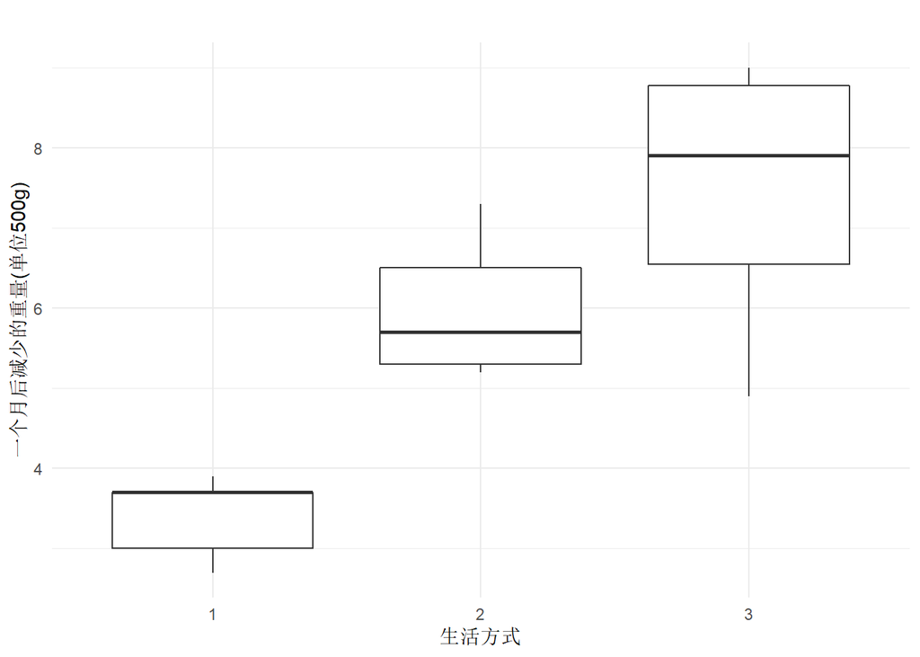

```r
#构建数据框，包含数据和该来自的处理组
df_meth <- data.frame(meth_value, meth_fac)
library(ggplot2)
#画箱线图
ggplot(df_meth, aes(x = meth_fac, y = meth_value)) +
  geom_boxplot() +
  theme_minimal() +
  labs(x = "生活方式", y = "一个月后减少的重量(单位500g)", title = "")
```

##检验位置参数是否相同

下面采用单因素方差分析法和Kruskal-Wallis检验，来检验位置参数是否相同。

###检验方法一：单因素方差分析法

```r
summary(aov(meth_value ~ meth_fac))
```

```
##             Df Sum Sq Mean Sq F value   Pr(>F)
## meth_fac     2  38.12  19.058   14.14 0.000912 ***
## Residuals   11  14.83   1.348
## ---
## Signif. codes:  0 '***' 0.001 '**' 0.01 '*' 0.05 '.' 0.1 ' ' 1
```

p=0.000912<0.05，拒绝原假设，认为位置参数不同。

###检验方法二：Kruskal-Wallis 单因素方差分析

```r
#进行Kruskal-Wallis检验
kruskal.test(meth_value, meth_fac)
```

```
##
##  Kruskal-Wallis rank sum test
##
## data:  meth_value and meth_fac
## Kruskal-Wallis chi-squared = 9.4322, df = 2, p-value = 0.00895
```

p=0.00895<0.05，拒绝原假设，认为位置参数不同。

因此，

两种检验都拒绝了原假设，认为三种生活方式的减肥效果（位置参数）不同。

##检验哪种生活方式的效果最好，哪种最差

由于Dunn检验只能进行双边检验，即只能检验两两之间是否有差异，而不能检验两两之间哪一组的位置参数更大。

所以选择Jonckheere-Terpstra检验，来检验哪种生活方式的减肥效果最好，哪种最差。

###Jonckheere-Terpstra检验

根据箱线图可以直观地看到，生活方式1的减肥效果最差，生活方式三最好。

下面通过Jonckheere-Terpstra检验进行严格的检验。

原假设和备择假设是：

$H_0:\theta_1=\theta_2=\theta_3 \ vs \ H_1:\theta_1≤\theta_2≤\theta_3$

即原假设是三种生活方式的减肥效果没有差别，备择假设是生活方式1的减肥效果最差，生活方式三最好。

但是，考虑到对位置参数的检验时，在备择假设是“三种生活方式的减肥效果有差别”时，已经拒绝了“三种生活方式的减肥效果没有差别”的原假设，

所以严谨起见，以下对所有$\theta_1,\theta_2,\theta_3$的6种排列分别进行作为备择假设中$\theta$的排列进行检验，即进行六次Jonckheere-Terpstra检验。

也就是

$$H_0:\theta_1=\theta_2=\theta_3 \ vs \ H_1:\theta_1≤\theta_2≤\theta_3 \\
H_0:\theta_1=\theta_3=\theta_2 \ vs \ H_1:\theta_1≤\theta_3≤\theta_2
\\
H_0:\theta_2=\theta_1=\theta_3 \ vs \ H_1:\theta_2≤\theta_1≤\theta_3
\\
H_0:\theta_2=\theta_3=\theta_1 \ vs \ H_1:\theta_2≤\theta_3≤\theta_1
\\
H_0:\theta_3=\theta_1=\theta_2 \ vs \ H_1:\theta_3≤\theta_1≤\theta_2
\\
H_0:\theta_3=\theta_2=\theta_1 \ vs \ H_1:\theta_3≤\theta_2≤\theta_1$$

R中有`SAGx`包中的`JT.test()`函数，`clinfun`包中的`jonckheere.test()`函数，`PMCMR`包中的`jonckheere.test()`函数都可以进行Jonckheere-Terpstra检验，仅输入的参数的类型略有差异，得到的p值是相同的。

####(1)首先进行备择假设是θ1≤θ2≤θ3的假设检验

用以上函数分别进行$H_0:\theta_1=\theta_2=\theta_3 \ vs \ H_1:\theta_1≤\theta_2≤\theta_3$的假设检验，得到的p值相同。

```r
library(SAGx)
#输入数据为矩阵类型，处理组的名称为因子类型
JT.test(data = t(c(meth1, meth2, meth3)), class = meth_fac, alternative = "increasing")
```

```
## class was not an ordered factor.  Redefined to be one.
```

```
##
##  Jonckheere-Terpstra
##
## data:  t(c(meth1, meth2, meth3)) by meth_fac
## J = 6, p-value = 0.0009567
## alternative hypothesis: increasing: 1 < 2 < 3
```

得到p=0.0009567

```r
library(clinfun)
meth_label <- c(rep(1,length(meth1)), rep(2,length(meth2)), rep(3, length(meth3)))
#输入数据为向量类型，处理组的名称为数字
clinfun::jonckheere.test(c(meth1, meth2, meth3), meth_label,
                alternative="increasing")
```

```
##
##  Jonckheere-Terpstra test
##
## data:
## JT = 59, p-value = 0.0009567
## alternative hypothesis: increasing
```

得到p=0.0009567

```r
library(PMCMR)
#输入数据为向量类型，处理组的名称为因子类型
PMCMR::jonckheere.test(c(meth1, meth2, meth3), meth_fac,
                alternative="increasing")
```

```
##
##  Jonckheere-Terpstrata test
##
## data:  c(meth1, meth2, meth3) and meth_fac
## Jonckheere z-value = 3.1034, p-value = 0.0009567
## alternative hypothesis: increasing
```

得到p=0.0009567

可以看到，三个函数进行Jonckheere-Terpstra检验得到的p值相同，都拒绝了原假设

####(2)三个函数的区别

**但是**，

`SAGx`包中的`JT.test()`函数，`clinfun`包中的`jonckheere.test()`函数在进行检验时，不管输入数据的处理组的顺序是什么，备择假设都是$H_1:\theta_1≤\theta_2≤\theta_3$。

以下改变输入数据的处理组的顺序为$\theta_3,\theta_2,\theta_1$，也就是试图进行原假设和备择假设为
$$H_0:\theta_3=\theta_2=\theta_1 \ vs\ H_1:\theta_3≤\theta_2≤\theta_1$$
的假设检验。可以通过箱线图直观地看到，这个备择假设是不正确的。我们期待得到的检验结果是无法拒绝原假设。

我们分别使用`SAGx`包中的`JT.test()`函数，`clinfun`包中的`jonckheere.test()`函数，`PMCMR`包中的`jonckheere.test()`函数进行检验。

下面这段代码仅用于说明这三个函数在备择假设上的区别，从而选择符合要求的函数进行后续的检验。

```r
values_temp <- c(meth3, meth2, meth1)
label_temp <- c(rep(3,length(meth3)), rep(2,length(meth2)), rep(1, length(meth1)))
fac_temp <- as.factor(c(rep(3,length(meth3)), rep(2,length(meth2)), rep(1, length(meth1))))

SAGx::JT.test(t(values_temp), fac_temp,
                alternative="increasing")$p.value
```

```
## class was not an ordered factor.  Redefined to be one.
```

```
## [1] 0.0009566765
```

```r
clinfun::jonckheere.test(values_temp, label_temp,
                alternative="increasing")$p.value
```

```
## [1] 0.0009566765
```

```r
PMCMR::jonckheere.test(values_temp, fac_temp,
                alternative="increasing")$p.value
```

```
##         1
## 0.9992163
```

可以看到，`SAGx`包中的`JT.test()`函数和`clinfun`包中的`jonckheere.test()`函数输出的p值均为p=0.0009567，和
$$H_0:\theta_1=\theta_2=\theta_3 \ vs\ H_1:\theta_1≤\theta_2≤\theta_3$$
情形下的p值相同，不符合预期。

只有`PMCMR`包中的`jonckheere.test()`函数进行了
$$H_0:\theta_3=\theta_2=\theta_1 \ vs\ H_1:\theta_3≤\theta_2≤\theta_1$$
的假设检验。

####(3)进行θ1,θ2,θ3的6中排列的6个假设检验

因此，下面选择`PMCMR`包中的`jonckheere.test()`函数对来进行$\theta_1,\theta_2,\theta_3$的6种排列的6个假设检验。

```r
#6种排列
meth_value_perm <- list(c(meth1, meth2, meth3),
                        c(meth1, meth3, meth2),
                        c(meth2, meth1, meth3),
                        c(meth2, meth3, meth1),
                        c(meth3, meth1, meth2),
                        c(meth3, meth2, meth1)
                        )
meth_fac_perm <- list(as.factor(c(rep(1,n1), rep(2,n2), rep(3, n3))),
                      as.factor(c(rep(1,n1), rep(3,n3), rep(2, n2))),
                      as.factor(c(rep(2,n2), rep(1,n1), rep(3, n3))),
                      as.factor(c(rep(2,n2), rep(3,n3), rep(1, n1))),
                      as.factor(c(rep(3,n3), rep(1,n1), rep(2, n2))),
                      as.factor(c(rep(3,n3), rep(2,n2), rep(1, n1)))
                      )
#用PMCMR包中的jonckheere.test()函数进行假设检验，返回p值
JT_permu_func <- function(dat, fac){
  PMCMR::jonckheere.test(dat, fac,
                alternative="increasing")$p.value
}
#进行检验
p_perm <- mapply(JT_permu_func, meth_value_perm, meth_fac_perm)
p_perm <- data.frame(p_perm)
rownames(p_perm) <- c("θ1≤θ2≤θ3", "θ1≤θ3≤θ2", "θ2≤θ1≤θ3", "θ2≤θ3≤θ1", "θ3≤θ1≤θ2", "θ3≤θ2≤θ1")
colnames(p_perm) <- c("不同备择假设下对应的p值")
#输出结果
knitr::kable(p_perm, format = "html")
```

|  | 不同备择假设下对应的p值 |
| --- | --- |
| θ1≤θ2≤θ3 | 0.0009567 |
| θ1≤θ3≤θ2 | 0.0266623 |
| θ2≤θ1≤θ3 | 0.4302797 |
| θ2≤θ3≤θ1 | 0.9767505 |
| θ3≤θ1≤θ2 | 0.6802622 |
| θ3≤θ2≤θ1 | 0.9992163 |

说明第三种生活方式的减肥效果最好，第一种生活方式效果最差。

这与箱线图的直观结果是一致的。

#新4.8(旧4.6)

分别进行Cochran检验和卡方检验。

##Cochran检验

```r
sale1 <- c(rep(1, 6), rep(0, 2), rep(1, 3), 0)
sale2 <- c(rep(c(0, 1), 2), rep(0, 3), 1, rep(0, 4))
sale3 <- c(rep(c(1, 0), 2), rep(c(0, 1), 2), rep(0, 3), 1)

#sale_matr是题给矩阵的转置
#每一列为一个推销员，每一行为一个客户
sale_matr <- matrix(c(sale1, sale2, sale3), nrow = 12, ncol = 3)
ni. <- apply(sale_matr, 1, sum)
n.j <- apply(sale_matr, 2, sum)
k <- ncol(sale_matr)
#检验统计量
Q <- (k-1)*((k*sum(n.j^2) - (sum(n.j))^2))/(k*sum(ni.) - sum(ni.^2))
#p值
p <- pchisq(Q, k-1, lower.tail = FALSE)
p
```

```
## [1] 0.07843739
```

##卡方检验

```r
obsfreq <- apply(sale_matr, 2, sum)
#原假设是三位推销员的推销能力相同，即顾客对三位推销员的推销服务的满意程度相同
nullprobs <- c(.333,.333,.334)
chisq.test(obsfreq, p = nullprobs)
```

```
##
##  Chi-squared test for given probabilities
##
## data:  obsfreq
## X-squared = 3.3012, df = 2, p-value = 0.1919
```

但是，从数据直观来看，三位推销员的推销能力是有差异的。

Cochran检验检测出了三位推销员之间的差异，而卡方检验没有检测出来。

另一方面，这里使用卡方检验是不合适的。因为卡方检验要求每位顾客满意的推销员有且仅有一个，本题中的数据不符合该要求。

所以，本题应该采用Cochran检验，不可以采用卡方检验。

#新4.9(旧4.7)

数据是均衡不完全区组BIB设计，且有

$$k = 4, \ b = 4, \ t = 3, \ r = 3, \ \lambda = 2$$

均衡不完全区组BIB设计满足以下条件：

(1)每个处理在同一区组中最多出现一次；

(2)区组样本量为$t=3$，$t$为每个区组设计的样本量，$t=3$小于处理个数$k=4$；

(3)每个处理出现在相同多的$r=3$个区组中；

(4)每两个处理在一个区组中相遇的次数一样，均为$\lambda = 2$次。

采用Durbin不完全区组分析法进行检验。

方法一按照公式计算检验统计量并求p值，方法二使用PMCMR包中的durbin.test()函数进行检验。

得到的p值一致。

##方法一：按照公式计算检验统计量并求p值

```r
#读入数据
#每行是一种处理，每列是一个区组
death_mosq <- matrix(c(
  356, 320, 359, NA,
  338, 340, NA, 385,
  372, NA, 380, 390,
  NA, 308, 332, 348),
  ncol = 4, nrow = 4, byrow = TRUE,
  dimnames = list(LETTERS[1:4], 1:4))

k <- 4
b <- 4
t <- 3
r <- 3
lambda <- 2

#计算Rij，即在第i个区组中第j个处理的秩
#空值NA不参与求秩，保持为NA不变
Rij <- apply(death_mosq, 2, function(x) rank(x, na.last = "keep"))

#计算每个区组的秩和Ri.
#求和时去掉NA
Ri._mosq <- apply(Rij, 1, function(x) sum(x, na.rm = TRUE))

#计算检验统计量D
D_mosq <- 12*(k-1)*(sum((Ri._mosq-0.5*r*(t+1))^2))/(r*k*(t^2-1))

#在零假设下，检验统计量D近似服从自由度为(k-1)的卡方分布
#p值
p_mosq <- 1 - pchisq(D_mosq, df = k-1)
p_mosq
```

```
## [1] 0.08030773
```

得到p=0.08030773>0.05

##方法二：使用PMCMR包中的durbin.test()函数进行检验

```r
library(PMCMR)
#参数中的矩阵要求每行是一个区组，每列是一种处理
durbin.test(t(death_mosq))
```

```
##
##  Durbin rank sum test
##
## data:  t(death_mosq)
## Durbin chi-squared = 6.75, df = 3, p-value = 0.08031
```

得到p=0.08031>0.05但是小于0.1

两种方法得到的p值相等，均为p=0.08031<0.1。因此可以在10%的显著性水平下拒绝原假设，认为四种驱蚊药剂的药效不同。